# **SENTIMENT ANALYSIS OF FLIPKART PRODUCT REVIEWS FOR CUSTOMER OPINION MINING**

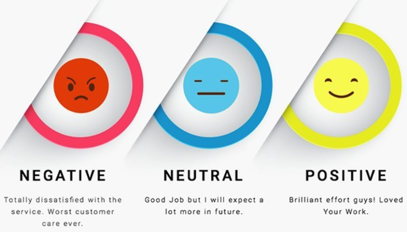

## **SUBJECT - M508 BIG DATA ANALYTICS**

## **STUDENT NAME - ASHISH TIWARI**

## **GH NUMBER - 1045433**

## **BUSINESS PROBLEM**

- Every day thousands of product reviews are sent to online retailers such as Flipkart "An e-commerce latform in INDIA".
- Through these reviews, customers can freely express their thoughts, complaints and experiences.
- Business cannot possibly read and comprehend so much crticism by hand.
- Because reviews are unstructured data in the form of text , many important customer insights are lost
- Business are unable to promptly recognize unfavourable comments and new problems
- Pricing, customer service, and product quality decisons are frequently postponed
- To make better decisions, a system that automatically evaluates customer sentiment from reviews is needed

## **PROBLEM STATEMENT**

- Flipkart product reviews provide indepth data about customer satisfaction and discontent
- The majority of company just use their star rating, which truely does'nt represent customer sentiments and emotions.
- Without automated techniques, text reviews are complex and challenging to evaluate.
- Inconsistent, biased, and time-consuming is manual review analysis.
- Positive, negative and neutral customer reviews are tugh to classify, specially the neutral reviews because they have certai kind of minor bias towards positive or negative.

## **OBJECTIVES**

- To examine consumer feed backgathered from Flipkart merchandise.
- To use NLP techniques to preprocess and clean the raw review text.
- To dtermine how each review express the sentiment of the customer
- To categorize review as Positive, Negative, Neutral
- To comprehend general consumer trends about various products.
- To assist companies in raising customer happiness and product quality.
- To illustrate how sentiment research might aid in e commerce platform decision making

## **DATASET LINK -**

https://www.kaggle.com/datasets/niraliivaghani/flipkart-product-customer-reviews-dataset

## **PHASE 1- DATA ACQUISITION**

**IMPORTING LIBRARIES**

To support the entire NLP workflow , several libraries are loaded. Data handling , text preprocessing, sentiment analysis, features extraction, model development, evaluation, visualization, and deep learning are all aided by them. Both conventional and sophisticated sentiment categorization techniques are made possible by tools like NLTK, scikit-learn, transformers, and Pytorch.

```python
%%capture
import nltk
import pandas as pd
from sklearn.model_selection import train_test_split
from sklearn.feature_extraction.text import CountVectorizer, TfidfVectorizer
from sklearn.linear_model import LogisticRegression
from sklearn.metrics import accuracy_score, precision_score, recall_score, f1_score, confusion_matrix, classification_report
from sklearn.preprocessing import label_binarize
from sklearn.metrics import roc_curve, auc
import matplotlib.pyplot as plt
import seaborn as sns
from nltk.tokenize import WhitespaceTokenizer
from nltk.corpus import stopwords, wordnet
from nltk.stem import WordNetLemmatizer
from nltk.tokenize import word_tokenize
from nltk.tag import pos_tag
from textblob import TextBlob
!pip install emoji
import emoji
!pip install rapidfuzz
from rapidfuzz import process, fuzz
from imblearn.over_sampling import SMOTE
!pip install gensim numpy
from gensim.models import Word2Vec
!pip install sentence-transformers
import transformers
from sentence_transformers import SentenceTransformer
!pip install evaluate
import evaluate
!pip install --upgrade transformers

!pip install spacy
!python -m spacy download en_core_web_sm
import spacy
import string
import re
import torch
from torch.utils.data import Dataset, DataLoader
from tqdm import tqdm
from transformers import DistilBertTokenizer, AutoModelForSequenceClassification, Trainer, TrainingArguments, DistilBertModel, RobertaTokenizer, RobertaForSequenceClassification
from transformers import AutoTokenizer
from datasets import Dataset
import numpy as np
from wordcloud import WordCloud, STOPWORDS
from textblob import Word
import warnings
warnings.filterwarnings("ignore")
print("All required libraries imported successfully.")

nltk.download('punkt', quiet=True)
nltk.download('stopwords', quiet=True)
nltk.download('wordnet', quiet=True)
nltk.download('omw-1.4', quiet=True)
nltk.download('averaged_perceptron_tagger_eng', quiet=True)
nltk.download('punkt_tab', quiet=True)
print("NLTK DATA DOWNLOADED.")
```

**LOADING DATASET**

```python
df = pd.read_csv("/content/Dataset-SA.csv")
```

**TAKING ONLY THE SAMPLE OF 10,000 FROM THE DATA SET**

```python
sample_n = df.sample(n=10000 , random_state=100)

print(f"\SAMPLED DATAFRAME SIZE (n=10000): {len(sample_n)} rows")
```

```
\SAMPLED DATAFRAME SIZE (n=10000): 10000 rows
```

**DATASET INFO**

```python
df.info()
```

```
<class 'pandas.core.frame.DataFrame'>
RangeIndex: 205052 entries, 0 to 205051
Data columns (total 6 columns):
 #   Column         Non-Null Count   Dtype
---  ------         --------------   -----
 0   product_name   205052 non-null  object
 1   product_price  205052 non-null  object
 2   Rate           205052 non-null  object
 3   Review         180388 non-null  object
 4   Summary        205041 non-null  object
 5   Sentiment      205052 non-null  object
dtypes: object(6)
memory usage: 9.4+ MB
```

**DATASET DESCRIBED**

```python
sample_n.shape
```

```
(10000, 6)
```

**DATASET COLOUMN**

```python
sample_n.columns
```

```
Index(['product_name', 'product_price', 'Rate', 'Review', 'Summary',
       'Sentiment'],
      dtype='object')
```

**DATASET HEADS**

```python
sample_n.head()
```

|  | product_name | product_price | Rate | Review | Summary | Sentiment |
| --- | --- | --- | --- | --- | --- | --- |
| 176390 | SUJATA by SUJATA Powermatic 900 W Juicer 1 Jar... | 5190 | 1 | hated it! | wastage of fruits is too much and pots become ... | negative |
| 114831 | Mi 5A 80 cm (32 inch) HD Ready LED Smart Andro... | 13999 | 3 | does the job | thanks flipkart to replace and ontime delivery... | positive |
| 198306 | cello Pack of 18 Opalware Cello Dazzle Lush Fi... | 1299 | 5 | fabulous! | love it | positive |
| 147156 | The Answer Writing Manual For UPSC Civil Servi... | 329 | 5 | perfect product! | good quality | positive |
| 81439 | sanyasi ayurveda Sanyasi Sehat Tablet - Ayurve... | 699 | 3 | decent product | very good i show effect in 15 days | positive |

**DATASET ENDING VIEW**

```python
sample_n.tail()
```

|  | product_name | product_price | Rate | Review | Summary | Sentiment |
| --- | --- | --- | --- | --- | --- | --- |
| 136972 | Blue Star BSAP490LAN Portable Room Air Purifie... | 11440 | 2 | could be way better | product is made of 15 months oldlocks of front... | negative |
| 62855 | Lakm?? Eyeconic Kajal Twin Pack??????????(Deep... | 218 | 5 | awesome | beautiful | positive |
| 4486 | etmax NANO BLACK 30 W Bluetooth Home Theatre??... | 997 | 4 | wonderful | he was is very nice speakar but he is not used... | positive |
| 56060 | Men Graphic Print Round Neck Black T-Shirt | 269 | 4 | NaN | nice | positive |
| 11332 | SportSoul Cotton Gym & Athletic Abdomen Suppor... | 249 | 5 | wonderful | comfortable and perfect for heavy physical act... | positive |

**DROPPING NAN VALUES**

```python
print(f"ORIGINAL SHAPE OF DATA FRAME: {sample_n.shape}")

sample_n.dropna(subset=['Summary', 'Sentiment'], inplace=True)
print(f"SHAPE AFTER DROPPING NaNs: {sample_n.shape}")
```

```
ORIGINAL SHAPE OF DATA FRAME: (10000, 6)
SHAPE AFTER DROPPING NaNs: (10000, 6)
```

## **PHASE 2- EXPLORATORY DATA ANALYSIS(EDA)**

**UNDERSTANDING SENTIMENT DISTRIBUTION**

These libraries are imported to analyze and visualize sentiment data effectively. Pandas is used to manipulate to create percentage and summarize sentiment counts , while matplotlib is used to create clear and informative vizualizations. Together, they help convert raw sentiment results into an easy t understand graphical representation for analysis and reporting. When combined, they aid in transforming unprocessed sentiment data into an understandable graphical representation for reporting analysis.

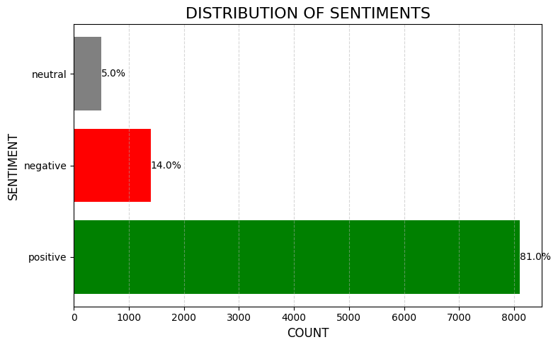

```python
sentiment_counts = sample_n["Sentiment"].value_counts()
total = sentiment_counts.sum()
percentages = sentiment_counts / total * 100

colors = {'positive':'green', 'neutral':'gray', 'negative':'red'}

plt.figure(figsize=(8, 5))
bars = plt.barh(sentiment_counts.index, sentiment_counts.values, color=[colors.get(x, 'blue') for x in sentiment_counts.index])

for bar, perc in zip(bars, percentages):
    plt.text(bar.get_width() + 0.5, bar.get_y() + bar.get_height()/2, f'{perc:.1f}%', va='center')

plt.xlabel("COUNT", fontsize=12)
plt.ylabel("SENTIMENT", fontsize=12)
plt.title("DISTRIBUTION OF SENTIMENTS", fontsize=16)

plt.grid(axis='x', linestyle='--', alpha=0.5)

plt.tight_layout()
plt.show()
```

**VIEWING REVIEW-SUMMARY LENGTH**

In order to determine the level of information in customer feedback, this section examines the legnth of review summaries. Each review summary's character count is determined, and a histogram is used to show distribution of those characters. While the mean and median refrence lines display the average and typical review length, color, intensity draws attentionto frequency variance. This makes it easier to spot reccuring themes and anomalies in consumer feedback.

```python
df["summary_length"] = df["Summary"].astype(str).apply(len)
```

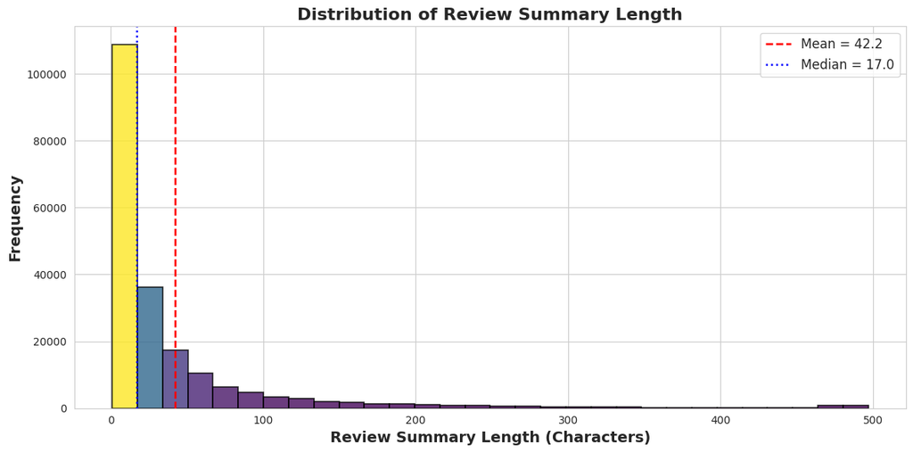

```python
sns.set_style("whitegrid")
plt.figure(figsize=(12,6))

n, bins, patches = plt.hist(
    df["summary_length"],
    bins=30,
    edgecolor='black',
    linewidth=1.2,
    alpha=0.8,
)

for patch, count in zip(patches, n):
    plt.setp(patch, 'facecolor', plt.cm.viridis(count / max(n)))

plt.xlabel("Review Summary Length (Characters)", fontsize=14, weight='bold')
plt.ylabel("Frequency", fontsize=14, weight='bold')
plt.title("Distribution of Review Summary Length", fontsize=16, weight='bold')

mean_len = df["summary_length"].mean()
median_len = df["summary_length"].median()
plt.axvline(mean_len, color='red', linestyle='dashed', linewidth=1.8, label=f"Mean = {mean_len:.1f}")
plt.axvline(median_len, color='blue', linestyle='dotted', linewidth=1.8, label=f"Median = {median_len:.1f}")

plt.legend(fontsize=12)

plt.tight_layout()
plt.show()
```

**WORD COUNT OF REVIEW-SUMMARY**

This section looks at how long review summaries are based on how many words customer use. Each review's summary word count is determined, and a histogram is used to show the distribution. IN addition to identifying frequent word legnth patterns and highlighting extreme instances of extremely short or very ong summaries, the visulization aids in understanding how succinct or torough the majority of customer summaries are

```python
df["summary_word_count"] = df["Summary"].astype(str).apply(lambda x: len(x.split()))
```

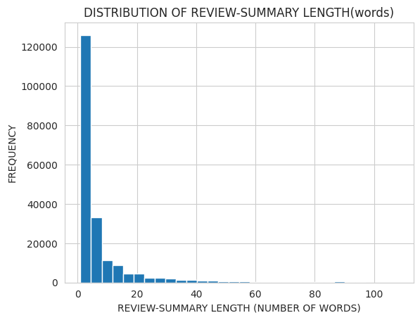

```python
plt.figure()
plt.hist(df["summary_word_count"], bins=30)
plt.xlabel("REVIEW-SUMMARY LENGTH (NUMBER OF WORDS)")
plt.ylabel("FREQUENCY")
plt.title("DISTRIBUTION OF REVIEW-SUMMARY LENGTH(words)")
plt.show()
```

**DISTRIBUTION OF STAR RATING**

IN order to comprehend overall product satisfaction, this section shows the distribution of customer star ratings. Each rating value is tallied and displayed in a pie chart with percentage labels. Redability is enhanced by color gradients and a little gap between slices. In order to determine if evaluation are primarily positive, neutral or negative the chart clearly illustrates how consumer input is distributed across various rating levels.

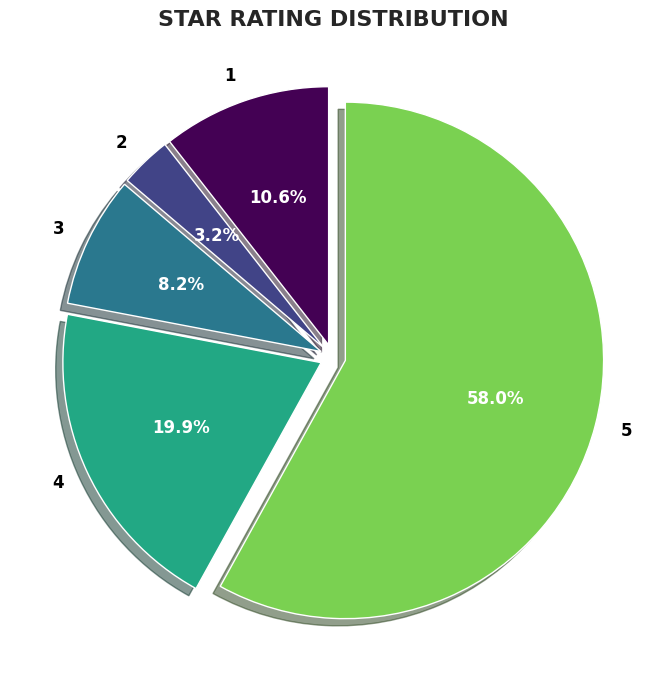

```python
sns.set_style("whitegrid")

rating_counts = sample_n["Rate"].value_counts().sort_index()

cmap = plt.get_cmap("viridis")
colors = [cmap(i / len(rating_counts)) for i in range(len(rating_counts))]

explode = [0.05]*len(rating_counts)

plt.figure(figsize=(7,7))
wedges, texts, autotexts = plt.pie(
    rating_counts,
    labels=[str(label).upper() for label in rating_counts.index],
    autopct="%1.1f%%",
    startangle=90,
    colors=colors,
    explode=explode,
    shadow=True,
    textprops={'fontsize': 12, 'weight': 'bold', 'color': 'white'}
)

plt.title("STAR RATING DISTRIBUTION", fontsize=16, weight='bold')

for text in texts:
    text.set_fontsize(12)
    text.set_weight('bold')
    text.set_color('black')

plt.tight_layout()
plt.show()
```

**RATING vs. SENTIMENT COMPARISON**

The connection between consumer sentiment and star rating is examined in this section. it compares the distribution of feelings (positive, negative and neutral) across various rating level using a count plot. Verifying if written sentiment matches numerical ratings is made easier by the display. Clarity is enhanced with annotated counts, which make it simpler to spot inconsistencies, pattern, and trends between customer evaluation and expressed emotions.

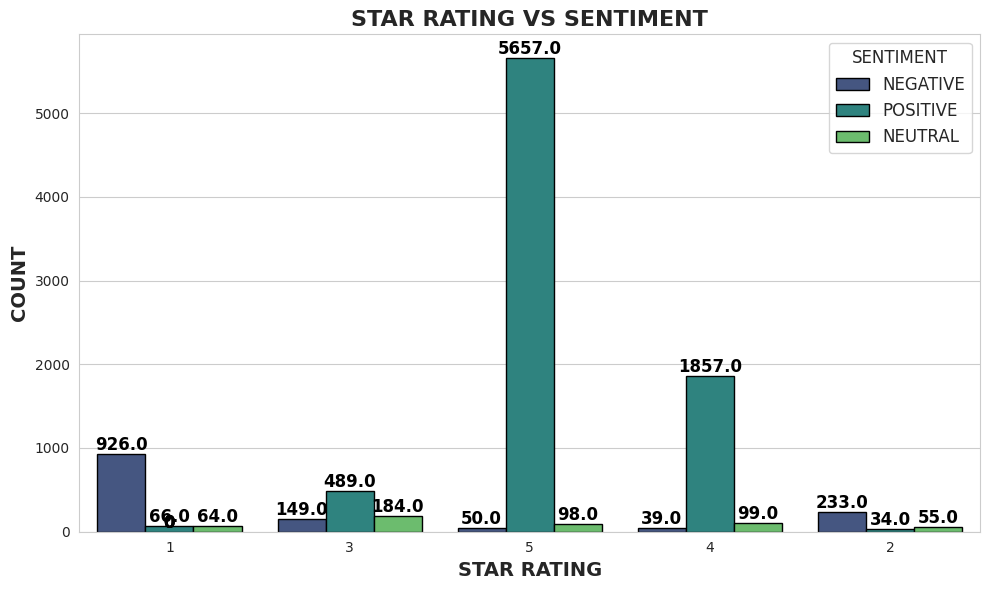

```python
sns.set_style("whitegrid")
plt.figure(figsize=(10,6))

palette = sns.color_palette("viridis", n_colors=sample_n["Sentiment"].nunique())
ax = sns.countplot(
    x="Rate",
    hue="Sentiment",
    data=sample_n,
    palette=palette,
    edgecolor='black'
)

plt.title("STAR RATING VS SENTIMENT", fontsize=16, weight='bold')
plt.xlabel("STAR RATING", fontsize=14, weight='bold')
plt.ylabel("COUNT", fontsize=14, weight='bold')

for p in ax.patches:
    height = p.get_height()
    ax.annotate(f'{height}',
                (p.get_x() + p.get_width() / 2., height),
                ha='center', va='bottom',
                fontsize=12, fontweight='bold', color='black')

handles, labels = ax.get_legend_handles_labels()
ax.legend(handles, [label.upper() for label in labels], title='SENTIMENT', title_fontsize=12, fontsize=12)

plt.tight_layout()
plt.show()
```

## **PHASE 3 -TEXT CLEANING(PRE-PROCESSING)**

**REMOVING NOISE THROUGH REGEX AND IMPLEMENTING WHITESPACE TOKENIZER**

Cleaning and preparing review material for sentiment analysis is the main goal of this part. When converting text to lowercase, it eliminates extreneous spaces, URLs, HTML tags, digits , emoticons, and mentions. For easier comprehension, emojis are translated into English. The text is made consistent and appropriated for additional NLP processing and model training by storing the cleaned summaries ina new coloumn.

```python
tokenizer = WhitespaceTokenizer()
def clean_text(text):
    if pd.isna(text):
        return ""

    text = emoji.demojize(str(text))
    text = text.lower()
    text = re.sub(r'http\S+|www\S+|https\S+', '', text)
    text = re.sub(r'<.*?>', '', text)
    text = re.sub(r'@\w+', '', text)
    text = re.sub(r'[:;XO][-]?[")("DPp]', '', text)
    text = re.sub(r'\d+', '', text)

    text = re.sub(r'\s+', ' ', text).strip()

    return text


sample_n["Cleaned_Summary"] = sample_n["Summary"].apply(clean_text)

print(sample_n.head())
```

```
                                             product_name product_price Rate  \
176390  SUJATA by SUJATA Powermatic 900 W Juicer 1 Jar...          5190    1
114831  Mi 5A 80 cm (32 inch) HD Ready LED Smart Andro...         13999    3
198306  cello Pack of 18 Opalware Cello Dazzle Lush Fi...          1299    5
147156  The Answer Writing Manual For UPSC Civil Servi...           329    5
81439   sanyasi ayurveda Sanyasi Sehat Tablet - Ayurve...           699    3

                  Review                                            Summary  \
176390         hated it!  wastage of fruits is too much and pots become ...
114831      does the job  thanks flipkart to replace and ontime delivery...
198306         fabulous!                                            love it
147156  perfect product!                                       good quality
81439     decent product                 very good i show effect in 15 days

       Sentiment                                    Cleaned_Summary
176390  negative  wastage of fruits is too much and pots become ...
114831  positive  thanks flipkart to replace and ontime delivery...
198306  positive                                            love it
147156  positive                                       good quality
81439   positive                    very good i show effect in days
```

**TOKENIZATION AND LOWER CASE CONVERSION**

In order to seperate each text intoo distinct words, this part tokenize the cleaned review summaries. To preserve consistency and minimize redudancy brought on by case changes, every token is converted into lower case. For every review, thegenerated tokens are saved as lists, making it simpler to do analysis like sentiment modeling, feature etraction, and frequency counting. Before beginning additional NLP activities, printing sample output aids in confirming proper prepration.

```python
tokenized_summaries = []
for summary_text in sample_n["Cleaned_Summary"]:

    tokens = word_tokenize(summary_text)

    tokens_lower = [token.lower() for token in tokens]
    tokenized_summaries.append(tokens_lower)

print("Tokenized and Lowercased Summaries (first 5 entries):")
for item in tokenized_summaries[:15]:
    print(item)
```

```
Tokenized and Lowercased Summaries (first 5 entries):
['wastage', 'of', 'fruits', 'is', 'too', 'much', 'and', 'pots', 'become', 'too', 'much', 'dirty', 'after', 'each', 'useits', 'gear', 'partially', 'damaged', 'by', 'single', 'usefeeling', 'sadness', 'to', 'purchase', 'this', 'juicer']
['thanks', 'flipkart', 'to', 'replace', 'and', 'ontime', 'delivery', 'of', 'mi', 'inch', 'tvregarding', 'mi', 'tv', 'picture', 'quality', 'is', 'very', 'good', 'needs', 'good', 'speed', 'of', 'internet', 'otherwise', 'lowcan', 'be', 'adjust', 'in', 'optionremote', 'is', 'interesting', 'with', 'googl…
['love', 'it']
['good', 'quality']
['very', 'good', 'i', 'show', 'effect', 'in', 'days']
['waste', 'of', 'money', 'please', 'note', 'no', 'return', 'option', 'available']
['very', 'impressive', 'with', 'this', 'size', 'of', 'speaker', 'with', 'the', 'good', 'sound', 'quality', 'really', 'a', 'great', 'product', 'ive', 'got', 'mi', 'smart', 'speakers', 'as', 'well', 'but', 'when', 'compared', 'with', 'the', 'size', 'its', 'really', 'good', 'thank', 'you', 'google', 'f…
['same', 'as', 'shop', 'smell', 'is', 'good', 'long', 'lasting', 'also', 'upto', 'hr', 'minimum']
['value', 'for', 'money', 'simply', 'styles', 'delivery', 'is', 'good']
['nice', 'product']
['not', 'bad']
['good']
['good', 'as', 'per', 'price']
['nice', 'prdctthnks', 'flpkrt']
['good']
```

**WORD CLOUD ACCORDING TO EACH SECTION OF SENTIMENT (WITH STOPWORDS ONLY FOR VISUALIZATION)**

In order to visually emphasize commonly used words in customer review summaries, this part creates sentiment-wise word clouds. Reviews are intially categorized into distinct text corpora based on sentiment (positive, negative, neutral). To make each sentiment category easily indentifiable, custom colorfunctions are used. By highlighting prominent terms, the word cloud makes it easier to spot reccurig themes, consumer sentients, and important issues that are represented in various sentiment goupings.

```python
def green_color_func(word, font_size, position, orientation, random_state=None, **kwargs):
    return "rgb(34, 139, 34)"
def red_color_func(word, font_size, position, orientation, random_state=None, **kwargs):
    return "rgb(178, 34, 34)"
def grey_color_func(word, font_size, position, orientation, random_state=None, **kwargs):
    return "rgb(105, 105, 105)"
```

```python
positive_text = " ".join(sample_n[sample_n["Sentiment"] == "positive"]["Cleaned_Summary"])
negative_text = " ".join(sample_n[sample_n["Sentiment"] == "negative"]["Cleaned_Summary"])
neutral_text  = " ".join(sample_n[sample_n["Sentiment"] == "neutral"]["Cleaned_Summary"])
```

```python
def generate_colored_wordcloud(text, title, color_func):
    wc = WordCloud(
        width=800,
        height=400,
        background_color="white",
        stopwords=STOPWORDS
    ).generate(text)

    plt.figure(figsize=(10, 5))
    plt.imshow(wc.recolor(color_func=color_func))
    plt.axis("off")
    plt.title(title)
    plt.show()
```

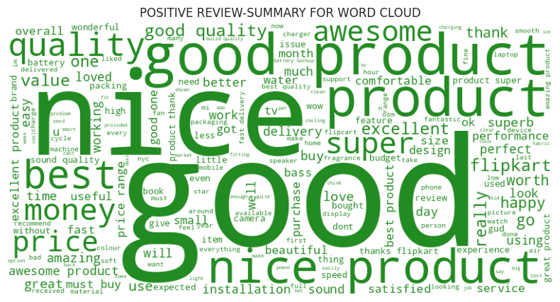

```python
generate_colored_wordcloud(
    positive_text,
    "POSITIVE REVIEW-SUMMARY FOR WORD CLOUD",
    green_color_func
)
```

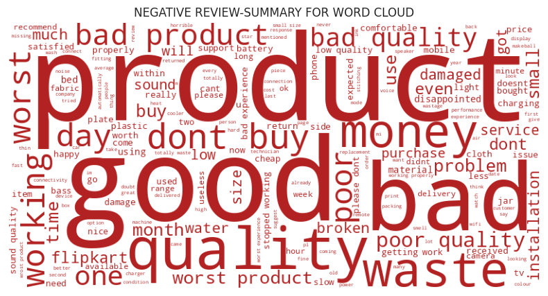

```python
generate_colored_wordcloud(
    negative_text,
    "NEGATIVE REVIEW-SUMMARY FOR WORD CLOUD",
    red_color_func
)
```

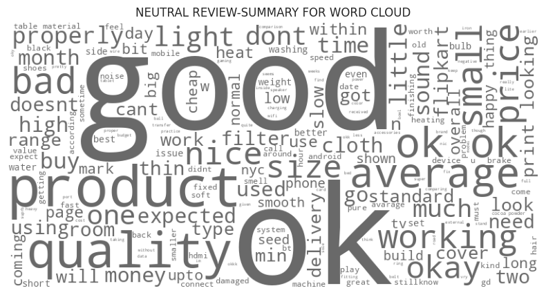

```python
generate_colored_wordcloud(
    neutral_text,
    "NEUTRAL REVIEW-SUMMARY FOR WORD CLOUD",
    grey_color_func
)
```

**MOST FREQUENT WORDS/N-GRAMS WITH STOP WORDS ONLY FOR VISUALIZATION**

Using n-grams analysis, the most common word patterns from cleaned review summaries are extracted and displayed in this section. A count vectorizer eliminates, common stopwords and counts instances of unigrams, bigrams and trigrams to transform text into numerical features. To find the most frequently used words and phrases, the frequencies are combined and sorted. The top n-grams are then displayed in bar charts, which makes it simple to see frequently stated features, customer complaints, and reccurent product related terms. In addition to enhancing feature comprehension and supporting improved customer opinion interpretation for sentiment modeling for business insightss, this approach aids in discovery of significant linguistic pattern.

```python
sns.set_style("whitegrid")

def top_ngrams(text, ngram_range, n=15):
    vec = CountVectorizer(ngram_range=ngram_range, stop_words = "english")
    X = vec.fit_transform(text)
    counts = X.sum(axis=0)

    data = [(word, counts[0, idx]) for word, idx in vec.vocabulary_.items()]
    df = pd.DataFrame(data, columns=["ngram", "count"])

    return df.sort_values("count", ascending=False).head(n)
```

```python
def plot_ngrams(df, title):
    plt.figure(figsize=(10, 5))
    sns.barplot(x="count", y="ngram", data=df)
    plt.title(title)
    plt.xlabel("Frequency")
    plt.ylabel("")
    plt.show()
```

**UNIGRAMS OR SINGLE WORDS**

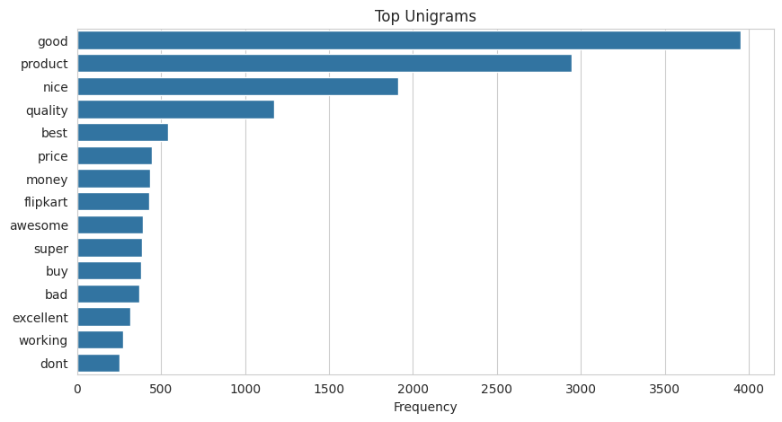

```python
unigrams = top_ngrams(sample_n["Cleaned_Summary"], (1,1))
plot_ngrams(unigrams, "Top Unigrams")
```

**BIGRAMS(TWO WORDS)**

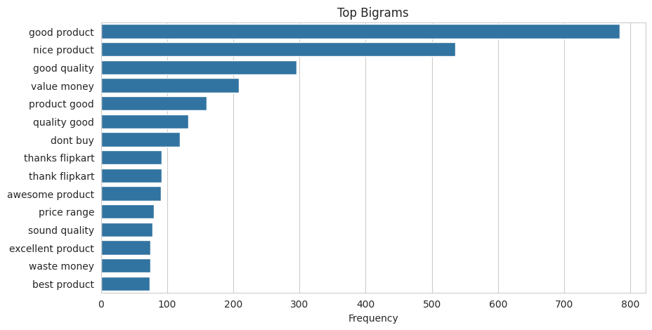

```python
bigrams = top_ngrams(sample_n["Cleaned_Summary"], (2,2))
plot_ngrams(bigrams, "Top Bigrams")
```

**TRIGRAMS (THREE WORDS)**

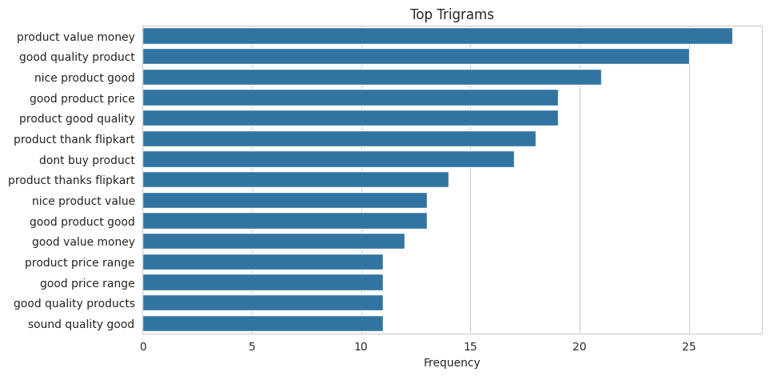

```python
trigrams = top_ngrams(sample_n["Cleaned_Summary"], (3,3))
plot_ngrams(trigrams, "Top Trigrams")
```

**PERFORMING POSTAGGING**

Part-of-speech (POS) tagging are mapped to their respective word net categories using a helper function defined in this section. This section of code snippet transforms tags like adjectives, verbs, nouns and adverbs into an appropriate format because word net lemmatization requires particular POS inputs. During text prepration, the fucntion helps reduce words to their semantic base forms by improving lemmatization accuracy through proper POS mapping

```python
def get_wordnet_pos(tag):
    """Map POS tag to WordNet POS for lemmatization"""
    if tag.startswith("J"):
        return wordnet.ADJ
    elif tag.startswith("V"):
        return wordnet.VERB
    elif tag.startswith("N"):
        return wordnet.NOUN
    elif tag.startswith("R"):
        return wordnet.ADV
    else:
        return wordnet.NOUN
```

```python
def pos_tag_text(text):

    if pd.isna(text):
        return []
    tokens = word_tokenize(text)
    return pos_tag(tokens)

sample_n["POS_Tags"] = sample_n["Cleaned_Summary"].apply(pos_tag_text)
print(sample_n[["Cleaned_Summary", "POS_Tags"]].head())
```

```
                                          Cleaned_Summary  \
176390  wastage of fruits is too much and pots become ...
114831  thanks flipkart to replace and ontime delivery...
198306                                            love it
147156                                       good quality
81439                     very good i show effect in days

                                                 POS_Tags
176390  [(wastage, NN), (of, IN), (fruits, NNS), (is, ...
114831  [(thanks, NNS), (flipkart, VBP), (to, TO), (re...
198306                            [(love, VB), (it, PRP)]
147156                        [(good, JJ), (quality, NN)]
81439   [(very, RB), (good, JJ), (i, NN), (show, VBP),...
```

**PERFORMING LEMMATTIZATION**

In order to increase linguistic accuracy,this section lemmatizes the review text using Part of speech data. The word net lemmatizer transforms each word and its POS tag into its base or dictionary form. The resuting lemmatized text maintains meaning while reducing grammatical variances. Cleaner, more consistent input for sentiment analysis model is made possible by storing the preprocessed output in a new coloumn.

```python
lemmatizer = WordNetLemmatizer()

def lemmatize_using_pos(pos_tagged_tokens):
    """Input: list of (word, POS) tuples → Output: lemmatized text string"""
    lemmatized_tokens = [
        lemmatizer.lemmatize(word, get_wordnet_pos(pos))
        for word, pos in pos_tagged_tokens
    ]
    return " ".join(lemmatized_tokens)

sample_n["Lemmatized_Text"] = sample_n["POS_Tags"].apply(lemmatize_using_pos)
print(sample_n[["Cleaned_Summary", "POS_Tags", "Lemmatized_Text"]].head(10))
```

```
                                          Cleaned_Summary  \
176390  wastage of fruits is too much and pots become ...
114831  thanks flipkart to replace and ontime delivery...
198306                                            love it
147156                                       good quality
81439                     very good i show effect in days
30742   waste of money please note no return option av...
25140   very impressive with this size of speaker with...
35731   same as shop smell is good long lasting also u...
129361     value for money simply styles delivery is good
54133                                        nice product

                                                 POS_Tags  \
176390  [(wastage, NN), (of, IN), (fruits, NNS), (is, ...
114831  [(thanks, NNS), (flipkart, VBP), (to, TO), (re...
```

[output cut: 20 more lines]

This section describes a function that expands the use of informal words and corrects typos in order to normalize review material. It automatically finds and fixes spelling errors that are frequently present in user generated reviews using Text-Blob. Robustness is ensured by managing missing values. This stage raises the quality of input data by increasing textual consistency and clarity, which improves feature extraction and produces more accurate sentimeny analysis results.

```python
def expand_contractions(text):
    if pd.isna(text):
        return ""
    blob = TextBlob(text)
    return str(blob.correct())

sample_n["Advanced_Cleaned"] = sample_n["Lemmatized_Text"].apply(expand_contractions)
print(sample_n[["Cleaned_Summary", "Lemmatized_Text", "Advanced_Cleaned"]].head())
```

```
                                          Cleaned_Summary  \
176390  wastage of fruits is too much and pots become ...
114831  thanks flipkart to replace and ontime delivery...
198306                                            love it
147156                                       good quality
81439                     very good i show effect in days

                                          Lemmatized_Text  \
176390  wastage of fruit be too much and pots become t...
114831  thanks flipkart to replace and ontime delivery...
198306                                            love it
147156                                       good quality
81439                      very good i show effect in day

                                         Advanced_Cleaned
176390  wastage of fruit be too much and pots become t...
114831  thanks flipkart to replace and time delivery o...
198306                                            love it
147156                                       good quality
81439                      very good i show effect in day
```

## **PHASE 4 FEATURE ENGINEERING**

**TRAIN-TEST SPLIT**

```python
X_text = sample_n["Advanced_Cleaned"]
y = sample_n["Sentiment"]
```

```python
X_train_text, X_test_text, y_train, y_test = train_test_split(
    X_text,
    y,
    test_size=0.25,
    stratify=y,
    random_state=100
)
```

**FEATURE 1- TF-IDF**

The TF_IDF(Term Frequency-Inverse Document Frequency) technique is used in this feature engineering stage to transform text into numerical features that are appropriate for machine learning models. In order to capture the significance of terms while lessening the influence of frequently occuring, less informative words, TF-IDF gives larger weights to words that are significant in a text but less prevalent across all publications.

With min_df =5 and max_df= 0.95, the vectorizer is set up to contain up to 8000 features, take into account unigrams to trigrmas, and disregard extremely rare or excessively common phrases. The model may now be trained using the converted training and test data (X_train and X_test)

```python
tfidf = TfidfVectorizer(
    max_features=8000,
    ngram_range=(1, 3),
    min_df=5,
    max_df=0.95
)

X_train = tfidf.fit_transform(X_train_text)
X_test = tfidf.transform(X_test_text)
```

**FEATURE 2- WORD2VEC**

```python
X_text_tokenized = sample_n["Advanced_Cleaned"]
y = sample_n["Sentiment"]

X_train_tokens, X_test_tokens, y_train, y_test = train_test_split(
    X_text_tokenized,
    y,
    test_size=0.25,
    stratify=y,
    random_state=100
)
```

```python
W2V_SIZE = 250
w2v_model = Word2Vec(
    sentences=X_train_tokens,
    vector_size=W2V_SIZE,
    window=6,
    min_count=5,
    sg=1,
    workers=8
)

print(f"Word2Vec Model Vocabulary Size: {len(w2v_model.wv.index_to_key)}")
```

```
WARNING:gensim.models.word2vec:Each 'sentences' item should be a list of words (usually unicode strings). First item here is instead plain <class 'str'>.
```

```
Word2Vec Model Vocabulary Size: 27
```

```python
def document_vector(model, doc):
    word_vectors = [model.wv[word] for word in doc if word in model.wv]
    if not word_vectors:
        return np.zeros(model.vector_size)
    return np.mean(word_vectors, axis=0)

X_train_w2v = np.array([document_vector(w2v_model, doc) for doc in X_train_tokens])
X_test_w2v = np.array([document_vector(w2v_model, doc) for doc in X_test_tokens])

print(f"Shape of X_train_w2v (for ML model): {X_train_w2v.shape}")
print(f"Shape of X_test_w2v (for ML model): {X_test_w2v.shape}")
```

```
Shape of X_train_w2v (for ML model): (7500, 250)
Shape of X_test_w2v (for ML model): (2500, 250)
```

**FEATURE 3 - DistilBERT**

Using DistilBERT, this feature engineering stage generates contextual embeddings for review text. First, the cleaned reviews are used to build training and testing sets with stratified sentiment distribution. DistilBERT tokenizer transforms text into token IDs with padding and truncation to a preset legnth in order to prepareit for the model

Following token processing,the DistilBERT model generates embeddings from the [CLS] token, representing each review as a dense numerical vector that encapsulates semantic and contextual meaning. These embeddings (X_train_dbert and X_test_dbert) are used as features for machine learning models, enhancing sentiment classification, by employing deep contextual represntations.

```python
X_text_bert = sample_n["Advanced_Cleaned"]
y_bert = sample_n["Sentiment"]

X_train_text, X_test_text, y_train_bert, y_test_bert = train_test_split(
    X_text_bert,
    y_bert,
    test_size=0.25,
    stratify=y_bert,
    random_state=100
)
```

```python
model_name = "distilbert-base-uncased"
tokenizer = DistilBertTokenizer.from_pretrained(model_name)
model = DistilBertModel.from_pretrained(model_name)

device = torch.device("cuda" if torch.cuda.is_available() else "cpu")
model.to(device)
print(f"Using device: {device}")
```

```
Using device: cuda
```

```python
def get_distilbert_embeddings(texts, model, tokenizer, device, max_len=128):
    model.eval()
    embeddings = []

    with torch.no_grad():
        for text in texts:

            inputs = tokenizer(
                text,
                return_tensors="pt",
                padding='max_length',
                truncation=True,
                max_length=max_len
            ).to(device)

            outputs = model(**inputs)

            cls_embedding = outputs.last_hidden_state[:, 0, :].cpu().numpy()
            embeddings.append(cls_embedding)

    return np.vstack(embeddings)
```

```python
print("Generating training embeddings... (Numerical Feature Engineering)")
X_train_dbert = get_distilbert_embeddings(X_train_text.tolist(), model, tokenizer, device)

print("Generating testing embeddings...")
X_test_dbert = get_distilbert_embeddings(X_test_text.tolist(), model, tokenizer, device)

print(f"\nFeature Engineering Complete:")
print(f"Shape of X_train_dbert: {X_train_dbert.shape}")
print(f"Shape of X_test_dbert: {X_test_dbert.shape}")
```

```
Generating training embeddings... (Numerical Feature Engineering)
Generating testing embeddings...

Feature Engineering Complete:
Shape of X_train_dbert: (7500, 768)
Shape of X_test_dbert: (2500, 768)
```

**DEALING WITH DATA IMBALNCE - (SMOTE)**

This data balacing stage(Synthetic Minority Oversampling TEchique) uses Sentence-BERT (all-MiniLM-L6-v2) to generate dense, fixed-legnth embeddings for every review that captures semantic meaning and context at the sentence level. By transforming text into numerical data suitable for machine learning algorithms, these embeddings preserve subtle linguistic connections that traditional approaches would miss. After applying sentiment labels to y, the embeddings serve as the feature matrix X.

THe class imbalance of the dataset is corrected using SMOTE. In order to produce balanced datasets (X_res, y_res), it generates synthetic cases for underrpresented sentiment classes. This improves generalization and predition accuracy by ensuring that models learn efficiently from each class.

```python
model = SentenceTransformer('all-MiniLM-L6-v2')
embeddings = model.encode(sample_n['Advanced_Cleaned'].tolist())
```

```
README.md: 0.00B [00:00, ?B/s]
```

```
vocab.txt: 0.00B [00:00, ?B/s]
```

```
tokenizer.json: 0.00B [00:00, ?B/s]
```

```python
X = embeddings
y = sample_n['Sentiment']

print(f'Original shape: {X.shape}, Class counts: {sample_n["Sentiment"].value_counts()}')
sm = SMOTE(random_state=100)
X_res, y_res = sm.fit_resample(X, y)
```

```
Original shape: (10000, 384), Class counts: Sentiment
positive    8103
negative    1397
neutral      500
Name: count, dtype: int64
```

```python
print(f'Resampled shape: {X_res.shape}, Class counts after SMOTE: {pd.Series(y_res).value_counts()}')
```

```
Resampled shape: (24309, 384), Class counts after SMOTE: Sentiment
negative    8103
positive    8103
neutral     8103
Name: count, dtype: int64
```

**VISUALIZATION AFTER SMOTE**

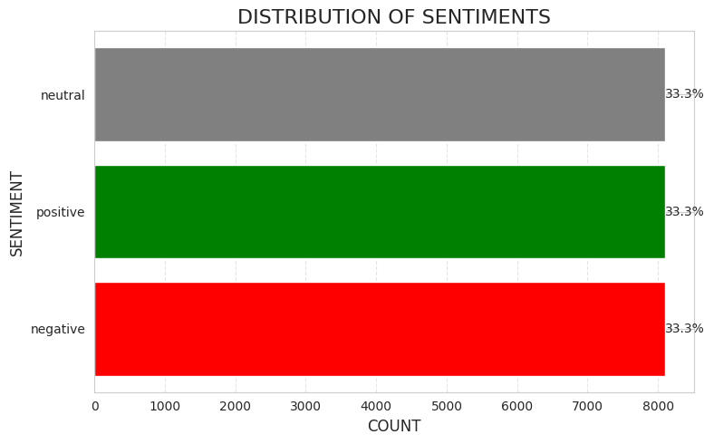

```python
sentiment_counts = pd.Series(y_res).value_counts()
total = sentiment_counts.sum()
percentages = sentiment_counts / total * 100

colors = {'positive':'green', 'neutral':'gray', 'negative':'red'}

plt.figure(figsize=(8, 5))
bars = plt.barh(sentiment_counts.index, sentiment_counts.values, color=[colors.get(x, 'blue') for x in sentiment_counts.index])

for bar, perc in zip(bars, percentages):
    plt.text(bar.get_width() + 0.5, bar.get_y() + bar.get_height()/2, f'{perc:.1f}%', va='center')

plt.xlabel("COUNT", fontsize=12)
plt.ylabel("SENTIMENT", fontsize=12)
plt.title("DISTRIBUTION OF SENTIMENTS", fontsize=16)

plt.grid(axis='x', linestyle='--', alpha=0.5)

plt.tight_layout()
plt.show()
```

## **PHASE 5 MODEL BUILDING**

**MODEL 1 - LOGISTIC REGRESSION (BASELINE)**

This phase involves employing an 80-20 ratio to divide the balanced dataset that was created after SMOTE into training and testing sets while maintaining class distribution. In order to guarantee convergence, Logistic Regression model is then initialized with a larger iteration limit. In order to predict positive, negative or neutral sentimentt for unseen review data in the testing set, the model is trained on the training set, the model is trained on the training set, discovering patterns in the embeddings and their correlation with sentiment labels.

```python
X_train, X_test, y_train, y_test = train_test_split(X_res, y_res, test_size=0.2, random_state=42, stratify=y_res)

classifier = LogisticRegression(max_iter=1000)
classifier.fit(X_train, y_train)
```

[output not shown]

**MODEL - 2 DistilBERT**

A DistilBERT model for sentiment classification is refined in this part. Three output labels-negative, neutral, and positive-are used to load the model for sequence classification. The review texts and labels are created, translated into Hugging Face dataset objects, and mapped to numerical values.The data is prepared for Pytorch and tokenized using truncation and padding.Batch size, learning rate, epochs, weight decay, and assesment approach are all defined by training arguments. Training and assesment are managed by the Trainer API. Following training, accuracy is used to assess the model's performance on the test set, yielding measures that show how effectively the refined DistilBERT predicts sentiment.

```python
device = torch.device("cuda" if torch.cuda.is_available() else "cpu")
print(f"Using device: {device}")

MODEL_NAME = "distilbert-base-uncased"
NUM_LABELS = 3

model = AutoModelForSequenceClassification.from_pretrained(
    MODEL_NAME,
    num_labels=NUM_LABELS
)
model.to(device)

accuracy_metric = evaluate.load("accuracy")

def compute_metrics(eval_pred):
    predictions, labels = eval_pred
    predictions = np.argmax(predictions, axis=1)
    return accuracy_metric.compute(predictions=predictions, references=labels)
```

```
Using device: cuda
```

```
Downloading builder script: 0.00B [00:00, ?B/s]
```

```python
label_mapping = {"negative": 0, "neutral": 1, "positive": 2}
y_train_mapped = y_train_bert.map(label_mapping)
y_test_mapped = y_test_bert.map(label_mapping)


train_df_for_bert = pd.DataFrame({'text': X_train_text.tolist(), 'labels': y_train_mapped.tolist()})
test_df_for_bert = pd.DataFrame({'text': X_test_text.tolist(), 'labels': y_test_mapped.tolist()})

raw_train_dataset = Dataset.from_pandas(train_df_for_bert)
raw_test_dataset = Dataset.from_pandas(test_df_for_bert)


def tokenize_function(examples):
    return tokenizer(examples["text"], truncation=True, padding="max_length")

tokenized_train = raw_train_dataset.map(tokenize_function, batched=True)
tokenized_test = raw_test_dataset.map(tokenize_function, batched=True)


tokenized_train = tokenized_train.remove_columns([col for col in tokenized_train.column_names if col in ["text", "__index_level_0__"]])
tokenized_test = tokenized_test.remove_columns([col for col in tokenized_test.column_names if col in ["text", "__index_level_0__"]])


tokenized_train = tokenized_train.with_format("torch", columns=["input_ids", "attention_mask", "labels"])
tokenized_test = tokenized_test.with_format("torch", columns=["input_ids", "attention_mask", "labels"])


training_args = TrainingArguments(
    output_dir="./distilbert_results",
    learning_rate=2e-5,
    per_device_train_batch_size=16,
    per_device_eval_batch_size=16,
    num_train_epochs=3,
    weight_decay=0.01,
    eval_strategy="epoch",
    save_strategy="epoch",
    load_best_model_at_end=True,
    report_to="none"
)

trainer = Trainer(
    model=model,
    args=training_args,
    train_dataset=tokenized_train,
    eval_dataset=tokenized_test,
    compute_metrics=compute_metrics,
)


print("STARTING DistilBert FINETUNING...")
trainer.train()
print("FINETUNING COMPLETE.")
```

```
STARTING DistilBert FINETUNING...
```

[1407/1407 19:21, Epoch 3/3]

| Epoch | Training Loss | Validation Loss | Accuracy |
| --- | --- | --- | --- |
| 1 | No log | 0.193914 | 0.937600 |
| 2 | 0.262300 | 0.220968 | 0.935200 |
| 3 | 0.152600 | 0.245200 | 0.937200 |

```
FINETUNING COMPLETE.
```

```python
results = trainer.evaluate()
print("\n*** FINAL TEST RESULTS IN (DistilBERT) ***")
print(results)
```

[157/157 00:38]

```
*** FINAL TEST RESULTS IN (DistilBERT) ***
{'eval_loss': 0.19391392171382904, 'eval_accuracy': 0.9376, 'eval_runtime': 38.5392, 'eval_samples_per_second': 64.869, 'eval_steps_per_second': 4.074, 'epoch': 3.0}
```

**MODEL 3 DistilRoBERTa**

A DistilRoBERTa model for sentiment classification is refined in this part. Three output labels-negative, neutraland positive are used to initialize the model and tokenizer. Sentiment labels are mapped to nuerical values and transformed into hugging face dataset objects in order to prepare training and testing datasets. Texts are prepared for pytorch and tokenized using padding and truncation. Learning rate, batch size, epochs, weight decay, and evaluation style are all specified by training inputs. Accuracy is the metric used by the trainer API to oversee training and assesment. Following fine-tuning, the model's performance is assesd on the test set, yielding sentiment prediction accuracy and loss measures.

```python
device = torch.device("cuda" if torch.cuda.is_available() else "cpu")
print(f"Using device: {device}")


MODEL_NAME = "distilroberta-base"
NUM_LABELS = 3
tokenizer = AutoTokenizer.from_pretrained(MODEL_NAME)
model = AutoModelForSequenceClassification.from_pretrained(MODEL_NAME, num_labels=NUM_LABELS).to(device)


label_mapping = {"negative":0, "neutral":1, "positive":2}
y_train_mapped = y_train_bert.map(label_mapping)
y_test_mapped = y_test_bert.map(label_mapping)

train_df = pd.DataFrame({'text': X_train_text.tolist(), 'labels': y_train_mapped.tolist()})
test_df = pd.DataFrame({'text': X_test_text.tolist(), 'labels': y_test_mapped.tolist()})

train_dataset = Dataset.from_pandas(train_df)
test_dataset = Dataset.from_pandas(test_df)
```

```
Using device: cuda
```

```python
def tokenize_fn(examples):
    return tokenizer(examples["text"], truncation=True, padding="max_length")
train_dataset = train_dataset.map(tokenize_fn, batched=True)
test_dataset = test_dataset.map(tokenize_fn, batched=True)


for ds in [train_dataset, test_dataset]:
    ds.set_format(type="torch", columns=["input_ids", "attention_mask", "labels"])


accuracy_metric = evaluate.load("accuracy")
def compute_metrics(eval_pred):
    logits, labels = eval_pred
    preds = np.argmax(logits, axis=1)
    return accuracy_metric.compute(predictions=preds, references=labels)


training_args = TrainingArguments(
    output_dir="./distilroberta_results",
    learning_rate=2e-5,
    per_device_train_batch_size=16,
    per_device_eval_batch_size=16,
    num_train_epochs=3,
    weight_decay=0.01,
    eval_strategy="epoch",
    save_strategy="epoch",
    load_best_model_at_end=True,
    metric_for_best_model="accuracy",
    logging_steps=10,
    report_to="none"
)
```

```python
trainer = Trainer(
    model=model,
    args=training_args,
    train_dataset=train_dataset,
    eval_dataset=test_dataset,
    compute_metrics=compute_metrics
)


print("STARTING DistilRoBERTa FINETUNING...")
trainer.train()
print("FINETUNING COMPLETE.")
```

```
STARTING DistilRoBERTa FINETUNING...
```

[1407/1407 19:21, Epoch 3/3]

| Epoch | Training Loss | Validation Loss | Accuracy |
| --- | --- | --- | --- |
| 1 | No log | 0.288936 | 0.942400 |
| 2 | 0.096000 | 0.270854 | 0.941600 |
| 3 | 0.137400 | 0.295123 | 0.941600 |

```
FINETUNING COMPLETE.
```

```python
print("\n*** FINAL TEST RESULTS ***")
test_results = trainer.evaluate(test_dataset)
for key, value in test_results.items():
    print(f"{key}: {value}")
```

```
*** FINAL TEST RESULTS ***
```

[157/157 00:34]

```
eval_loss: 0.270854115486145
eval_accuracy: 0.9416
eval_runtime: 34.6477
eval_samples_per_second: 72.155
eval_steps_per_second: 4.531
epoch: 3.0
```

## **PHASE 6 EVALUATION & VISUALIZATIONS**

**LOGISTIC REGRESSION METRICS**

This section uses a variety of indicators to asses the logistic regression model's performance on the test set. For every emotion class, precision, recall, and F1- score are provided via the classifiaction_report. The algorithm can forecast positive, neutral, and negative ratings, according to these measurements. A confuion matrix highlights misclassification patterns by displaying both accurate and incorrect predictions across classes. A bar chart is used to present class-wise F1- scores for easier comparison. To further evaluate the model's capacity for class diffrentiation, ROC curves and AOC curves for each class are utilized. When combined, these metrics offer a thorough grasp of the model's accuracy, dependability, and flexibility over a range of sentiment categories.

```python
y_pred = classifier.predict(X_test)

print(classification_report(y_test, y_pred))
```

```
              precision    recall  f1-score   support

    negative       0.91      0.92      0.92      1620
     neutral       0.85      0.87      0.86      1621
    positive       0.92      0.89      0.90      1621

    accuracy                           0.89      4862
   macro avg       0.89      0.89      0.89      4862
weighted avg       0.89      0.89      0.89      4862
```

**VISUALIZATIONS**

**CONFUSION MATRIX for LOGISTIC REGRESSION**

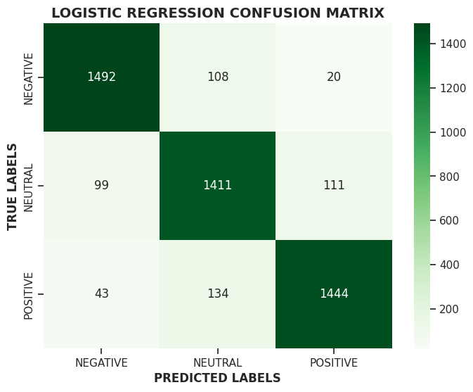

```python
cm = confusion_matrix(y_test, y_pred)
labels = np.unique(y_test)

plt.figure(figsize=(8,6))
sns.set(style="ticks")
sns.heatmap(cm, annot=True, fmt='d', cmap='Greens', cbar=True, xticklabels=[str(l).upper() for l in labels], yticklabels=[str(l).upper() for l in labels])
plt.xlabel("PREDICTED LABELS", fontsize=12, fontweight='bold')
plt.ylabel("TRUE LABELS", fontsize=12, fontweight='bold')
plt.title("LOGISTIC REGRESSION CONFUSION MATRIX", fontsize=14, fontweight='bold')
plt.show()
```

**F1 SCORE PER CLASS for LOGISTIC REGRESSION**

[figure not shown]

```python
f1_scores = f1_score(y_test, y_pred, average=None)
plt.figure(figsize=(8,5))
sns.barplot(x=[str(l).upper() for l in labels], y=f1_scores, palette="Greens_r")
plt.ylim(0, 1)
plt.ylabel("F1-SCORE", fontsize=12, fontweight='bold')
plt.xlabel("CLASSES", fontsize=12, fontweight='bold')
plt.title("LOGISTIC REGRESSION F1-SCORE PER CLASS", fontsize=14, fontweight='bold')
plt.show()
```

**ROC CURVE for LOGISTIC REGRESSION**

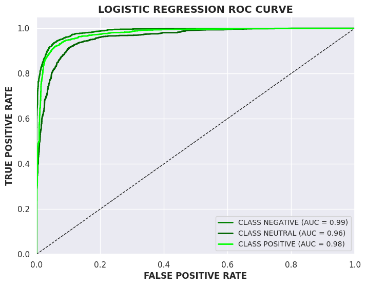

```python
classes = np.unique(y_test)
y_test_bin = label_binarize(y_test, classes=classes)
y_score = classifier.predict_proba(X_test)

plt.figure(figsize=(8,6))
colors = ['green', 'darkgreen', 'lime']  # adjust if more classes
for i, color in zip(range(len(classes)), colors):
    fpr, tpr, _ = roc_curve(y_test_bin[:, i], y_score[:, i])
    roc_auc = auc(fpr, tpr)
    plt.plot(fpr, tpr, color=color, lw=2, label=f'CLASS {str(classes[i]).upper()} (AUC = {roc_auc:.2f})')

plt.plot([0, 1], [0, 1], 'k--', lw=1)
plt.xlim([0.0, 1.0])
plt.ylim([0.0, 1.05])
plt.xlabel('FALSE POSITIVE RATE', fontsize=12, fontweight='bold')
plt.ylabel('TRUE POSITIVE RATE', fontsize=12, fontweight='bold')
plt.title('LOGISTIC REGRESSION ROC CURVE', fontsize=14, fontweight='bold')
plt.legend(loc='lower right', fontsize=10)
plt.grid(True)
plt.show()
```

**DistilBERT METRICS**

```python
outputs = trainer.predict(tokenized_test)
y_pred_logits = outputs.predictions
y_pred_distilbert = np.argmax(y_pred_logits, axis=1)

y_true_distilbert = y_test_mapped.tolist()

accuracy = accuracy_score(y_true_distilbert, y_pred_distilbert)
precision = precision_score(y_true_distilbert, y_pred_distilbert, average='weighted')
recall = recall_score(y_true_distilbert, y_pred_distilbert, average='weighted')
f1 = f1_score(y_true_distilbert, y_pred_distilbert, average='weighted')
conf_matrix = confusion_matrix(y_true_distilbert, y_pred_distilbert)
class_report = classification_report(y_true_distilbert, y_pred_distilbert)

print("=== DistilBERT Evaluation ===")
print(f"Accuracy: {accuracy:.4f}")
print(f"Precision: {precision:.4f}")
print(f"Recall: {recall:.4f}")
print(f"F1-score: {f1:.4f}")
print("\nConfusion Matrix:")
print(conf_matrix)
print("\nClassification Report:")
print(class_report)
```

```
=== DistilBERT Evaluation ===
Accuracy: 0.7292
Precision: 0.7097
Recall: 0.7292
F1-score: 0.7100

Confusion Matrix:
[[  21   54  274]
 [   6   23   96]
 [  58  189 1779]]

Classification Report:
              precision    recall  f1-score   support

           0       0.25      0.06      0.10       349
           1       0.09      0.18      0.12       125
           2       0.83      0.88      0.85      2026

    accuracy                           0.73      2500
   macro avg       0.39      0.37      0.36      2500
weighted avg       0.71      0.73      0.71      2500
```

**VISUALIZATIONS**

**CONFUSION MATRIX(DISTILBERT)**

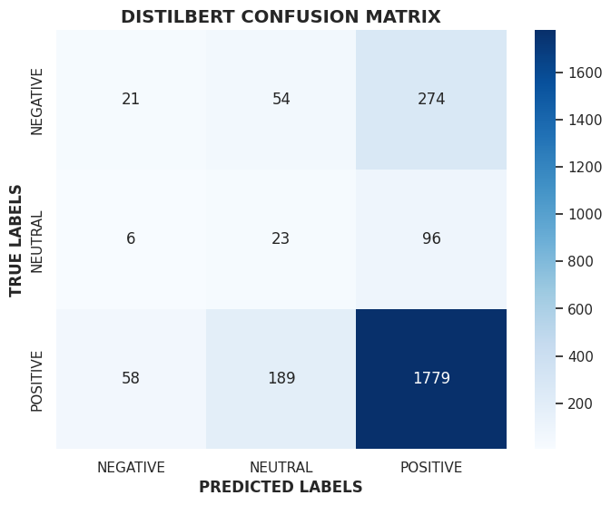

```python
cm = confusion_matrix(y_true_distilbert, y_pred_distilbert)


label_names = {0: 'negative', 1: 'neutral', 2: 'positive'}
plot_labels = [label_names[i] for i in sorted(label_names.keys())]

plt.figure(figsize=(8,6))
sns.set(style="whitegrid")
sns.heatmap(cm, annot=True, fmt='d', cmap='Blues', cbar=True,
            xticklabels=[str(l).upper() for l in plot_labels],
            yticklabels=[str(l).upper() for l in plot_labels])
plt.xlabel("PREDICTED LABELS", fontsize=12, fontweight='bold')
plt.ylabel("TRUE LABELS", fontsize=12, fontweight='bold')
plt.title("DISTILBERT CONFUSION MATRIX", fontsize=14, fontweight='bold')
plt.show()
```

**F1 SCORES PER CLASS for(DISTILBERT)**

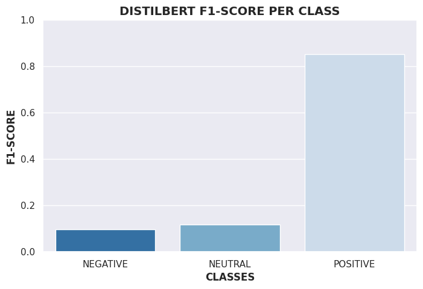

```python
f1_scores = f1_score(y_true_distilbert, y_pred_distilbert, average=None)
plt.figure(figsize=(8,5))
sns.barplot(x=[str(l).upper() for l in plot_labels], y=f1_scores, palette="Blues_r")
plt.ylim(0, 1)
plt.ylabel("F1-SCORE", fontsize=12, fontweight='bold')
plt.xlabel("CLASSES", fontsize=12, fontweight='bold')
plt.title("DISTILBERT F1-SCORE PER CLASS", fontsize=14, fontweight='bold')
plt.show()
```

**ROC CURVE for DISTILBERT**

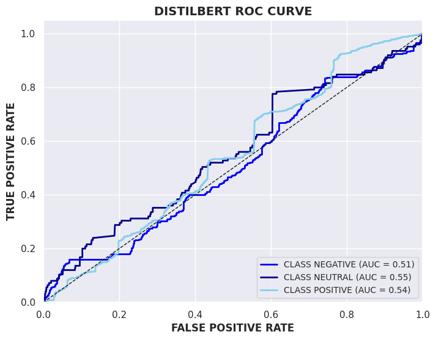

```python
classes = np.unique(y_true_distilbert)

y_test_bin = label_binarize(y_true_distilbert, classes=classes)

y_score = y_pred_logits

plt.figure(figsize=(8,6))
colors = ['blue', 'darkblue', 'skyblue']
for i, color in zip(range(len(classes)), colors):

    fpr, tpr, _ = roc_curve(y_test_bin[:, i], y_score[:, i])
    roc_auc = auc(fpr, tpr)
    plt.plot(fpr, tpr, color=color, lw=2, label=f'CLASS {str(label_names[classes[i]]).upper()} (AUC = {roc_auc:.2f})')

plt.plot([0, 1], [0, 1], 'k--', lw=1)
plt.xlim([0.0, 1.0])
plt.ylim([0.0, 1.05])
plt.xlabel('FALSE POSITIVE RATE', fontsize=12, fontweight='bold')
plt.ylabel('TRUE POSITIVE RATE', fontsize=12, fontweight='bold')
plt.title('DISTILBERT ROC CURVE', fontsize=14, fontweight='bold')
plt.legend(loc='lower right', fontsize=10)
plt.grid(True)
plt.show()
```

**DistilRoBERTa METRICS**

Several performance metrix are used same as other two models, but hthis model made sure to outperform the other two model. It compares model logits with actual values after converting them into sentiment labels, Whilee confusion matrix class wise f! plots , and ROC-AUC curve shoowcases class imbalance and descrimination abilities across sentiments metrics suchas accuracy , precision, recall, and F1 score gauge overall performance

```python
outputs_roberta = trainer.predict(test_dataset)
y_pred_logits_roberta = outputs_roberta.predictions
y_pred_distilroberta = np.argmax(y_pred_logits_roberta, axis=1)

y_true_distilroberta = y_test_mapped.tolist()

accuracy = accuracy_score(y_true_distilroberta, y_pred_distilroberta)
precision = precision_score(y_true_distilroberta, y_pred_distilroberta, average='weighted')
recall = recall_score(y_true_distilroberta, y_pred_distilroberta, average='weighted')
f1 = f1_score(y_true_distilroberta, y_pred_distilroberta, average='weighted')
conf_matrix = confusion_matrix(y_true_distilroberta, y_pred_distilroberta)
class_report = classification_report(y_true_distilroberta, y_pred_distilroberta)

print("=== DistilRoBERTa Evaluation ===")
print(f"Accuracy: {accuracy:.4f}")
print(f"Precision: {precision:.4f}")
print(f"Recall: {recall:.4f}")
print(f"F1-score: {f1:.4f}")
print("\nConfusion Matrix:")
print(conf_matrix)
print("\nClassification Report:")
print(class_report)
```

```
=== DistilRoBERTa Evaluation ===
Accuracy: 0.9416
Precision: 0.9368
Recall: 0.9416
F1-score: 0.9382

Confusion Matrix:
[[ 304   17   28]
 [  21   57   47]
 [  20   13 1993]]

Classification Report:
              precision    recall  f1-score   support

           0       0.88      0.87      0.88       349
           1       0.66      0.46      0.54       125
           2       0.96      0.98      0.97      2026

    accuracy                           0.94      2500
   macro avg       0.83      0.77      0.80      2500
weighted avg       0.94      0.94      0.94      2500
```

**VISUALIZATIONS**

**CONFUSION MATRIX FOR DISTILROBERTA**

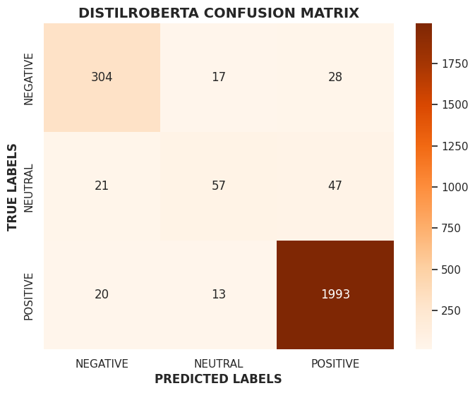

```python
cm = confusion_matrix(y_true_distilroberta, y_pred_distilroberta)

label_names = {0: 'negative', 1: 'neutral', 2: 'positive'}
plot_labels = [label_names[i] for i in sorted(label_names.keys())]

plt.figure(figsize=(8,6))
sns.set(style="darkgrid")
sns.heatmap(cm, annot=True, fmt='d', cmap='Oranges', cbar=True, xticklabels=[str(l).upper() for l in plot_labels], yticklabels=[str(l).upper() for l in plot_labels])
plt.xlabel("PREDICTED LABELS", fontsize=12, fontweight='bold')
plt.ylabel("TRUE LABELS", fontsize=12, fontweight='bold')
plt.title("DISTILROBERTA CONFUSION MATRIX", fontsize=14, fontweight='bold')
plt.show()
```

**F1 SCORE FOR DISTILROBERTA**

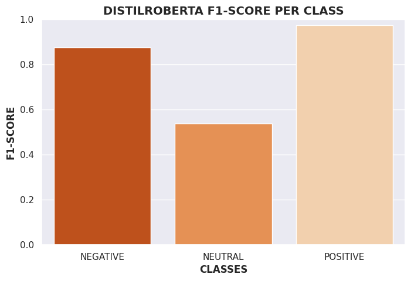

```python
f1_scores = f1_score(y_true_distilroberta, y_pred_distilroberta, average=None)
plt.figure(figsize=(8,5))
sns.barplot(x=[str(l).upper() for l in plot_labels], y=f1_scores, palette="Oranges_r")
plt.ylim(0, 1)
plt.ylabel("F1-SCORE", fontsize=12, fontweight='bold')
plt.xlabel("CLASSES", fontsize=12, fontweight='bold')
plt.title("DISTILROBERTA F1-SCORE PER CLASS", fontsize=14, fontweight='bold')
plt.show()
```

**ROC CURVE FOR DISTILROBERTA**

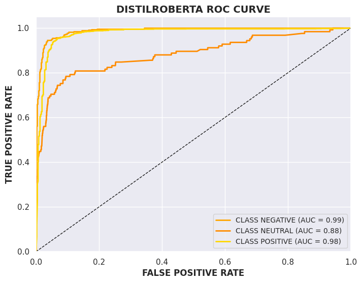

```python
classes = np.unique(y_true_distilroberta)

y_test_bin = label_binarize(y_true_distilroberta, classes=classes)

y_score = y_pred_logits_roberta

plt.figure(figsize=(8,6))
colors = ['orange', 'darkorange', 'gold']
for i, color in zip(range(len(classes)), colors):


    label_name = label_names[classes[i]]
    fpr, tpr, _ = roc_curve(y_test_bin[:, i], y_score[:, i])
    roc_auc = auc(fpr, tpr)
    plt.plot(fpr, tpr, color=color, lw=2, label=f'CLASS {str(label_name).upper()} (AUC = {roc_auc:.2f})')

plt.plot([0, 1], [0, 1], 'k--', lw=1)
plt.xlim([0.0, 1.0])
plt.ylim([0.0, 1.05])
plt.xlabel('FALSE POSITIVE RATE', fontsize=12, fontweight='bold')
plt.ylabel('TRUE POSITIVE RATE', fontsize=12, fontweight='bold')
plt.title('DISTILROBERTA ROC CURVE', fontsize=14, fontweight='bold')
plt.legend(loc='lower right', fontsize=10)
plt.grid(True)
plt.show()
```

**CONCLUSION TABLE**

[output not shown]

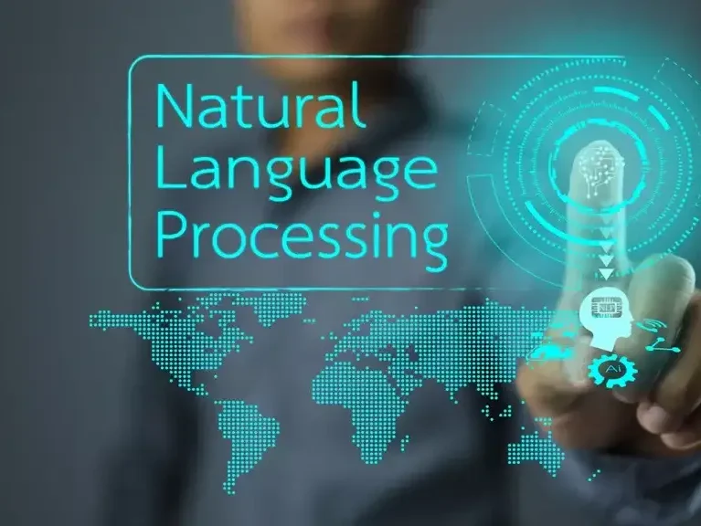